# Texas Machine Learning 2

Xianbin Cheng

May 11, 2018

## Method

1. Load the libraries and read in the files.

```r
library(tidyverse)
library(caret)
library(randomForest)
library(rpart)
library(rpart.plot)
library(party)
library(doParallel)
```

```r
X_Conc = read.csv("TX X_Conc_1008_obs.csv", header = TRUE, row.names = 1)
X_norm_Conc = read.csv("TX X_norm_Conc_1008_obs.csv", header = TRUE, row.names = 1)
```

```r
str(X_Conc, list.len = 10)
```

```
## 'data.frame':    1008 obs. of  1568 variables:
##  $ Spec_ID_all: Factor w/ 1008 levels "HH1-000001.dat",..: 481 490 491 492 493 494 495 496 497 498 ...
##  $ AF_class   : Factor w/ 2 levels "H","L": 2 2 2 2 2 2 2 2 2 2 ...
##  $ FM_class   : Factor w/ 3 levels "H","L","M": 2 2 2 2 2 2 2 2 2 2 ...
##  $ X304       : num  -2.18 -3.85 -1.55 -1 -1.92 ...
##  $ X304.5     : num  -0.888 -5.136 -1.226 -1.004 -2.568 ...
##  $ X305       : num  -0.498 -6.024 -1.204 -1.004 -3.112 ...
##  $ X305.5     : num  -2.11 -6.02 -1.85 -1 -3.43 ...
##  $ X306       : num  -3.71 -6.02 -2.49 -1 -3.76 ...
##  $ X306.5     : num  -4.84 -5.9 -2.95 -1 -3.83 ...
##  $ X307       : num  -3.87 -5.26 -2.63 -1 -2.87 ...
##   [list output truncated]
```

```r
str(X_norm_Conc, list.len = 10)
```

```
## 'data.frame':    1008 obs. of  1568 variables:
##  $ Spec_ID_all: Factor w/ 1008 levels "HH1-000001.dat",..: 481 490 491 492 493 494 495 496 497 498 ...
##  $ AF_class   : Factor w/ 2 levels "H","L": 2 2 2 2 2 2 2 2 2 2 ...
##  $ FM_class   : Factor w/ 3 levels "H","L","M": 2 2 2 2 2 2 2 2 2 2 ...
##  $ X304       : num  -1.003 -1.659 -0.757 -0.543 -0.904 ...
##  $ X304.5     : num  -0.458 -2.08 -0.587 -0.502 -1.099 ...
##  $ X305       : num  -0.198 -2.28 -0.464 -0.389 -1.183 ...
##  $ X305.5     : num  -0.579 -2.223 -0.47 -0.117 -1.136 ...
##  $ X306       : num  -0.983 -1.999 -0.444 0.209 -1.001 ...
##  $ X306.5     : num  -1.268 -1.733 -0.445 0.405 -0.83 ...
##  $ X307       : num  -1.2399 -1.8554 -0.6879 0.0338 -0.7942 ...
##   [list output truncated]
```

3. Extract out the texts and labels. Convert the predictor data frame into a matrix. Convert class “M” into “H”.

```r
AF = X_Conc[ ,"AF_class"] %>% as.character()
FM = X_Conc[ ,"FM_class"] %>% as.character()

summary(as.factor(AF))
```

```
##   H   L
##  12 996
```

```r
summary(as.factor(FM))
```

```
##   H   L   M
##  70 924  14
```

```r
AF[which(AF == "M")] = "H"
FM[which(FM == "M")] = "H"

AF = as.factor(AF)
FM = as.factor(FM)

summary(AF)
```

```
##   H   L
##  12 996
```

```r
summary(FM)
```

```
##   H   L
##  84 924
```

```r
X = X_Conc %>%
  select(-c(Spec_ID_all, AF_class, FM_class)) %>%
  as.matrix()

X_norm = X_norm_Conc %>%
  select(-c(Spec_ID_all, AF_class, FM_class)) %>%
  as.matrix()
```

```r
X[1:5,1:10]
```

```
##        X304     X304.5       X305    X305.5      X306    X306.5      X307
## 1 -2.175509 -0.8882276 -0.4984915 -2.106541 -3.714591 -4.838856 -3.873420
## 2 -3.848930 -5.1361660 -6.0243620 -6.024362 -6.024362 -5.903371 -5.259765
## 3 -1.547987 -1.2261640 -1.2035030 -1.846729 -2.489955 -2.951764 -2.629946
## 4 -1.004105 -1.0041050 -1.0041050 -1.004105 -1.004105 -1.004105 -1.004105
## 5 -1.924507 -2.5681480 -3.1119580 -3.433563 -3.755167 -3.834819 -2.869366
##      X307.5       X308     X308.5
## 1 -2.907985 -2.0081920 -2.0081920
## 2 -4.616158 -4.0163130 -4.0163130
## 3 -2.308129 -1.9863100 -1.6644870
## 4 -1.004105 -0.9822229 -0.6603938
## 5 -1.903914 -1.0478680 -1.6915090
```

```r
X_norm[1:5, 1:10]
```

```
##         X304     X304.5       X305     X305.5       X306     X306.5
## 1 -1.0027082 -0.4577402 -0.1982671 -0.5793093 -0.9830429 -1.2684535
## 2 -1.6591733 -2.0803340 -2.2796863 -2.2232311 -1.9990331 -1.7329309
## 3 -0.7565380 -0.5868225 -0.4638224 -0.4702919 -0.4443670 -0.4450628
## 4 -0.5431790 -0.5020021 -0.3887156 -0.1167260  0.2092082  0.4047550
## 5 -0.9042428 -1.0994229 -1.1826766 -1.1361291 -1.0008909 -0.8303642
##          X307     X307.5       X308     X308.5
## 1 -1.23993662 -1.1150946 -0.9655801 -1.0556793
## 2 -1.85535645 -1.8260290 -1.7181545 -1.8627259
## 3 -0.68793942 -0.8654370 -0.9573794 -0.9175472
## 4  0.03379636 -0.3227077 -0.5810822 -0.5140107
## 5 -0.79422163 -0.6972044 -0.6056838 -0.9284071
```

2. Exploratory analysis
- Build a single decision tree to get a sense of which features might be important for classification.
- Look at the density feature plots for wavelengths that were split on in the decision tree.

```r
## Train a single tree model on X_norm to classify aflatoxin level.
class_tree_af = rpart(AF ~ X_norm)

## Train a single tree model on X_norm to classify fumonisin level.
class_tree_fm = rpart(FM ~ X_norm)
```

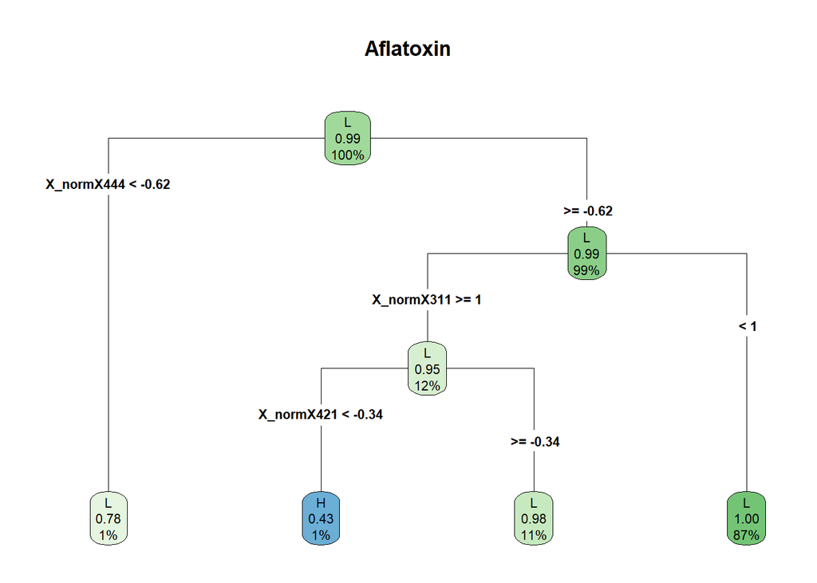

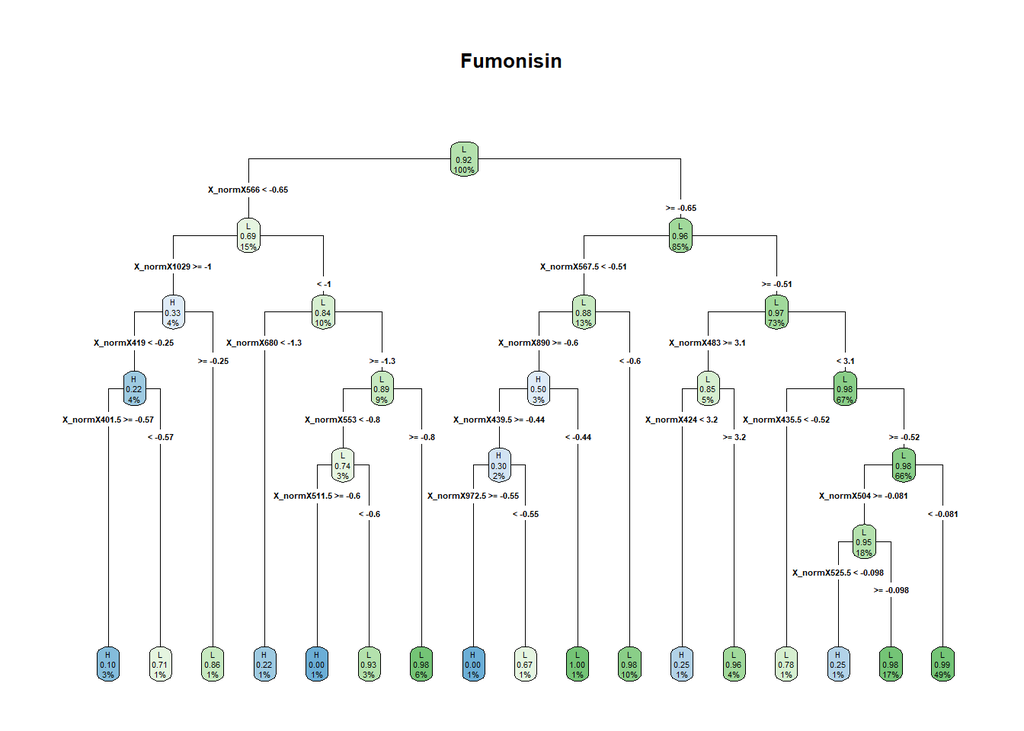

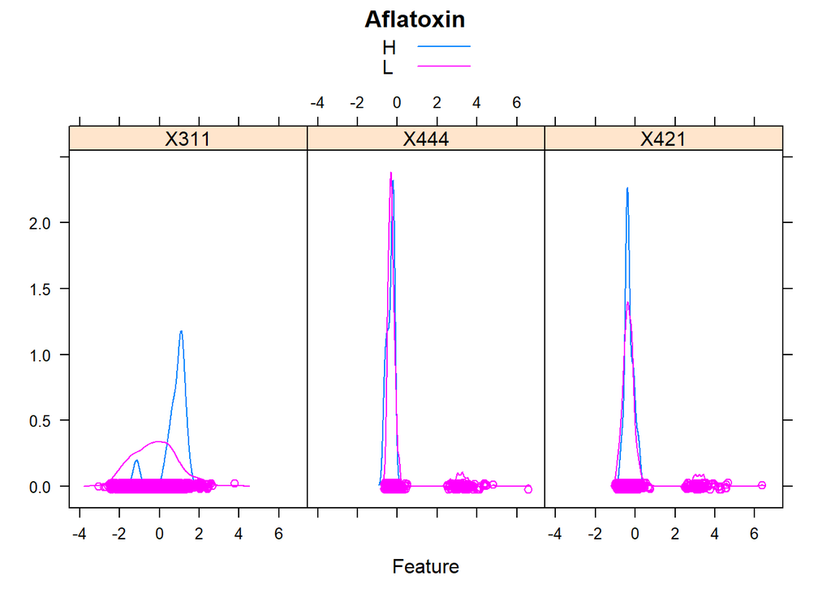

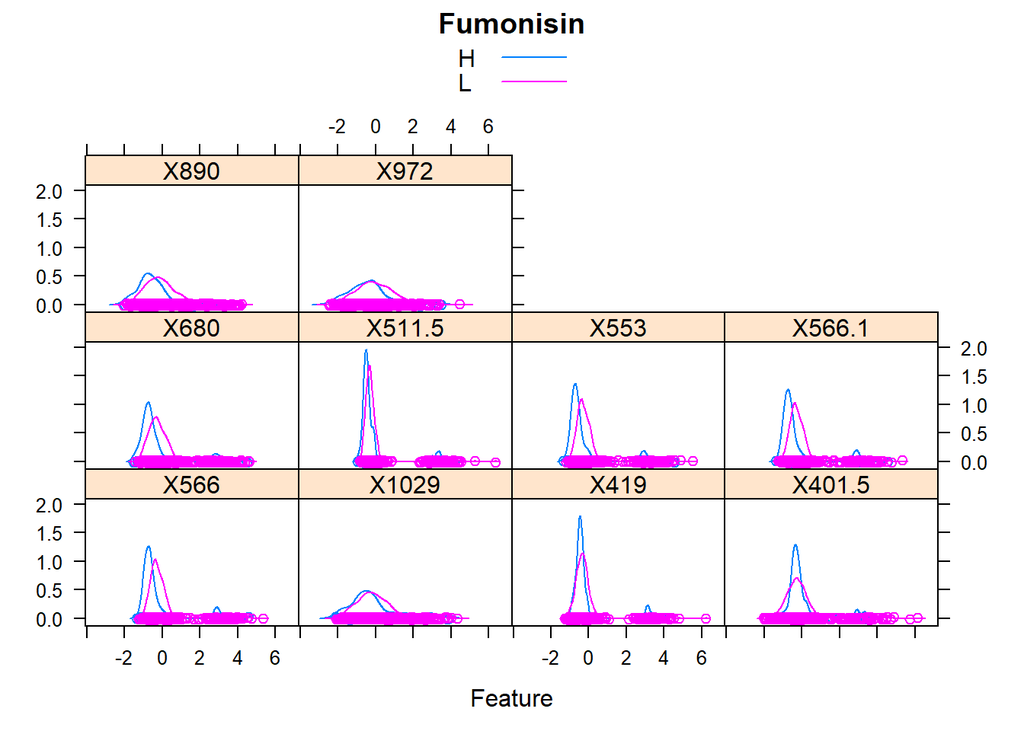

3. Create a training set and a test set with a test-train split ratio of 25:75.

```r
set.seed(123)
trn_ind_af = createDataPartition(y = AF, p = 0.75, list = FALSE)
trn_ind_fm = createDataPartition(y = FM, p = 0.75, list = FALSE)
```

4. We will consider the following method:
- Random forest (`rf`)
  - `mtry` = 19, 24, 29, 34, 39, 44, 49, 54, 59
  - Calculate 5-fold cross validation error with “ROC” as performance metric
  - Calculate importance

For each method we will consider only one set of features:

- Additive: All 1565 features

We will also consider different types of pre-processing:

- None
- Normalized (centered and scaled)

The model training process will be accelerated by parallelization.

```r
cl = makeCluster(detectCores() - 2)
registerDoParallel(cl)
```

```r
mtry_chosen = floor(sqrt(ncol(X)))
cv_5 = trainControl(method = "cv",
                    number = 5,
                    classProbs = TRUE,
                    summaryFunction = twoClassSummary,
                    allowParallel = TRUE)
```

```r
## Pre-processing: None
set.seed(123)
mod_rf_af = train(x = X[trn_ind_af, ],
                  y = AF[trn_ind_af],
                  xtest = X[-trn_ind_af, ],
                  ytest = AF[-trn_ind_af],
                  method = "rf",
                  importance = TRUE,
                  keep.forest = TRUE,
                  metric = "ROC",
                  trControl = cv_5,
                  tuneGrid = expand.grid(mtry = seq(from = mtry_chosen - 20, to = mtry_chosen + 20, by = 5))
)

set.seed(123)
mod_rf_fm = train(x = X[trn_ind_fm, ],
                  y = FM[trn_ind_fm],
                  xtest = X[-trn_ind_fm, ],
                  ytest = FM[-trn_ind_fm],
                  method = "rf",
                  importance = TRUE,
                  keep.forest = TRUE,
                  metric = "ROC",
                  trControl = cv_5,
                  tuneGrid = expand.grid(mtry = seq(from = mtry_chosen - 20, to = mtry_chosen + 20, by = 5))
)
```

```r
## Pre-processing: Normalized
set.seed(123)
mod_rf_norm_af = train(x = X_norm[trn_ind_af, ],
                  y = AF[trn_ind_af],
                  xtest = X_norm[-trn_ind_af, ],
                  ytest = AF[-trn_ind_af],
                  method = "rf",
                  importance = TRUE,
                  keep.forest = TRUE,
                  metric = "ROC",
                  trControl = cv_5,
                  tuneGrid = expand.grid(mtry = seq(from = mtry_chosen - 20, to = mtry_chosen + 20, by = 5))
)

set.seed(123)
mod_rf_norm_fm = train(x = X_norm[trn_ind_fm, ],
                  y = FM[trn_ind_fm],
                  xtest = X_norm[-trn_ind_fm, ],
                  ytest = FM[-trn_ind_fm],
                  method = "rf",
                  importance = TRUE,
                  keep.forest = TRUE,
                  metric = "ROC",
                  trControl = cv_5,
                  tuneGrid = expand.grid(mtry = seq(from = mtry_chosen - 20, to = mtry_chosen + 20, by = 5))
)
```

## Result

1. Show the classification error rate for all the models as well as the cross validatio ROC plot for tuning `mtry`.

```r
plot_sens_spec = function(model){
  df = model$results %>%
    select(mtry, ROC, Sens, Spec) %>%
    gather(data = ., key = "Type", value = "Value", -mtry)

  ggplot(data = df, aes(x = mtry, y = Value, color = Type)) +
    geom_line() +
    geom_point() +
    theme_bw()
}
```

```r
## Transformation: none. Classification: Aflatoxin.
mod_rf_af$finalModel
```

```
##
## Call:
##  randomForest(x = x, y = y, xtest = ..1, ytest = ..2, mtry = param$mtry,      importance = TRUE, keep.forest = TRUE)
##                Type of random forest: classification
##                      Number of trees: 500
## No. of variables tried at each split: 44
##
##         OOB estimate of  error rate: 1.19%
## Confusion matrix:
##   H   L class.error
## H 0   9           1
## L 0 747           0
##                 Test set error rate: 1.19%
## Confusion matrix:
##   H   L class.error
## H 0   3           1
## L 0 249           0
```

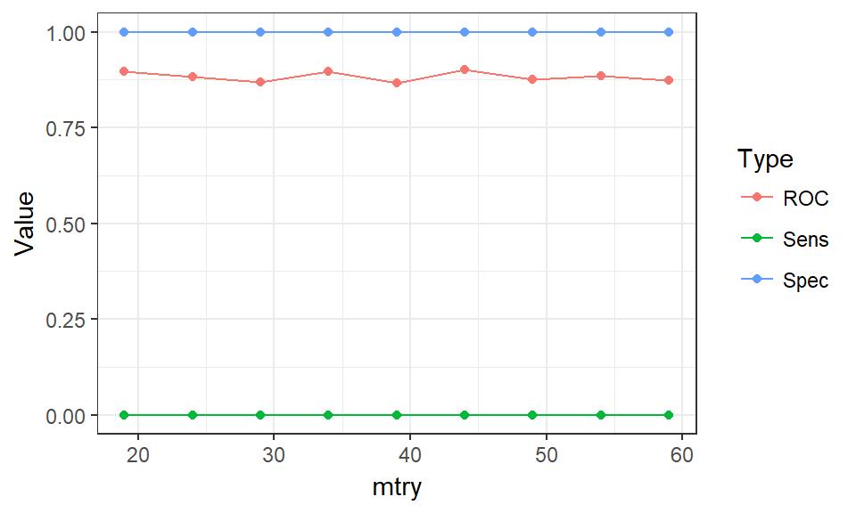

```r
plot_sens_spec(mod_rf_af)
```

```r
## Transformation: none. Classification: Fumonisin.
mod_rf_fm$finalModel
```

```
##
## Call:
##  randomForest(x = x, y = y, xtest = ..1, ytest = ..2, mtry = param$mtry,      importance = TRUE, keep.forest = TRUE)
##                Type of random forest: classification
##                      Number of trees: 500
## No. of variables tried at each split: 19
##
##         OOB estimate of  error rate: 7.8%
## Confusion matrix:
##    H   L class.error
## H 13  50  0.79365079
## L  9 684  0.01298701
##                 Test set error rate: 8.33%
## Confusion matrix:
##   H   L class.error
## H 4  17  0.80952381
## L 4 227  0.01731602
```

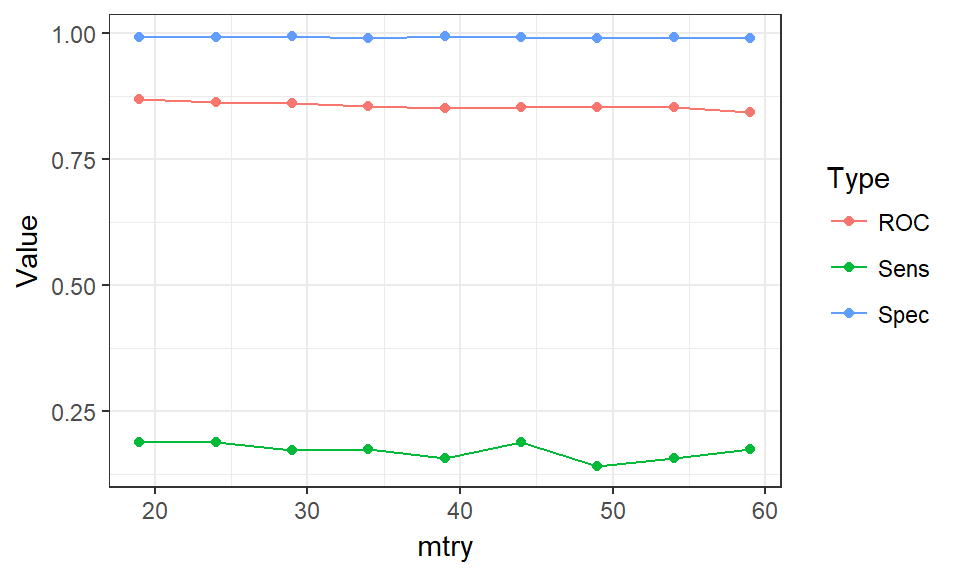

```r
plot_sens_spec(mod_rf_fm)
```

```r
## Transformation: normalized. Classification: Aflatoxin.
mod_rf_norm_af$finalModel
```

```
##
## Call:
##  randomForest(x = x, y = y, xtest = ..1, ytest = ..2, mtry = param$mtry,      importance = TRUE, keep.forest = TRUE)
##                Type of random forest: classification
##                      Number of trees: 500
## No. of variables tried at each split: 34
##
##         OOB estimate of  error rate: 1.19%
## Confusion matrix:
##   H   L class.error
## H 0   9           1
## L 0 747           0
##                 Test set error rate: 1.19%
## Confusion matrix:
##   H   L class.error
## H 0   3           1
## L 0 249           0
```

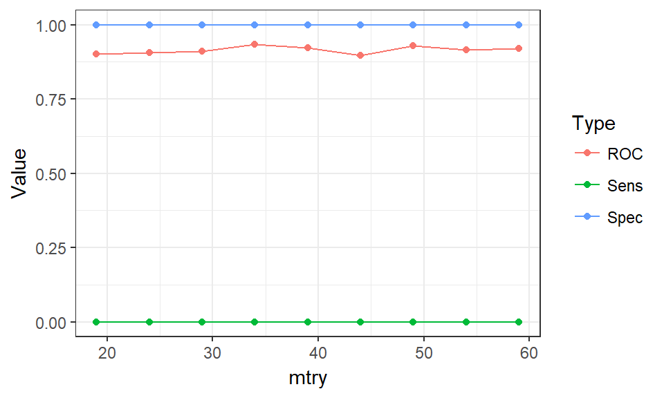

```r
plot_sens_spec(mod_rf_norm_af)
```

```r
## Transformation: normalized. Classification: Fumonisin.
mod_rf_norm_fm$finalModel
```

```
##
## Call:
##  randomForest(x = x, y = y, xtest = ..1, ytest = ..2, mtry = param$mtry,      importance = TRUE, keep.forest = TRUE)
##                Type of random forest: classification
##                      Number of trees: 500
## No. of variables tried at each split: 19
##
##         OOB estimate of  error rate: 7.14%
## Confusion matrix:
##    H   L class.error
## H 19  44  0.69841270
## L 10 683  0.01443001
##                 Test set error rate: 8.33%
## Confusion matrix:
##   H   L class.error
## H 4  17  0.80952381
## L 4 227  0.01731602
```

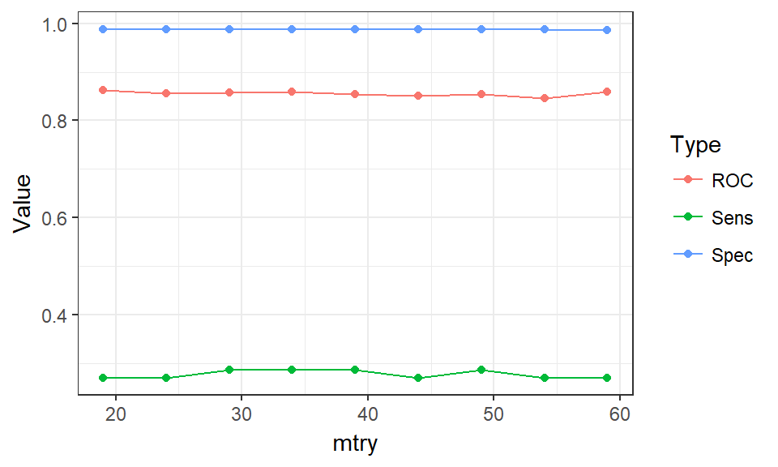

```r
plot_sens_spec(mod_rf_norm_fm)
```

2. Show the importance plots.

```r
## Create a function for visualizing mean decrease in accuracy.
MDA = function(model){
  a = importance(model) %>% as.data.frame()
  wl = gsub(pattern = "X", replacement = "", x = rownames(a)) %>% as.numeric()

  ggplot(data = a) +
    geom_point(aes(x = wl, y = a$MeanDecreaseAccuracy, color = a$MeanDecreaseAccuracy)) +
    scale_color_gradient(low="grey", high="darkgreen", name="") +
    labs(x="Wavelength (nm)", y="Mean Decrease in Accuracy") +
    theme_bw()
}
```

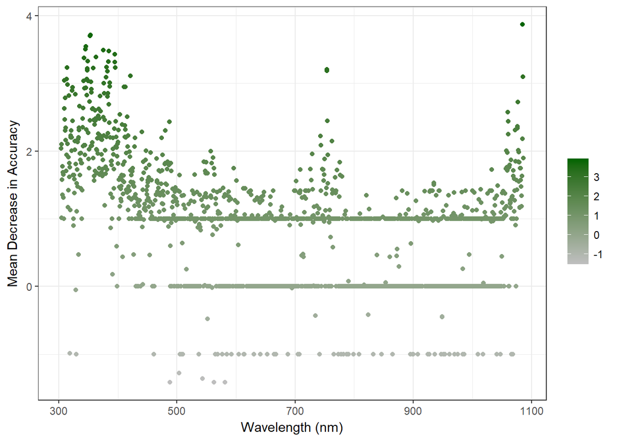

```r
## Transformation: none. Classification: Aflatoxin.
MDA(mod_rf_af$finalModel)
```

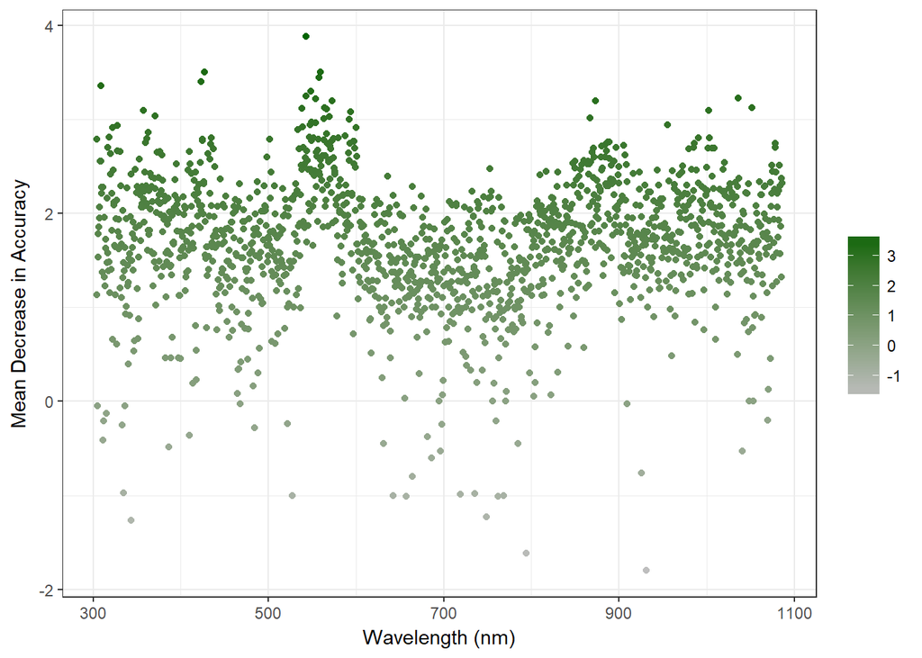

```r
## Transformation: none. Classification: Fumonisin.
MDA(mod_rf_fm$finalModel)
```

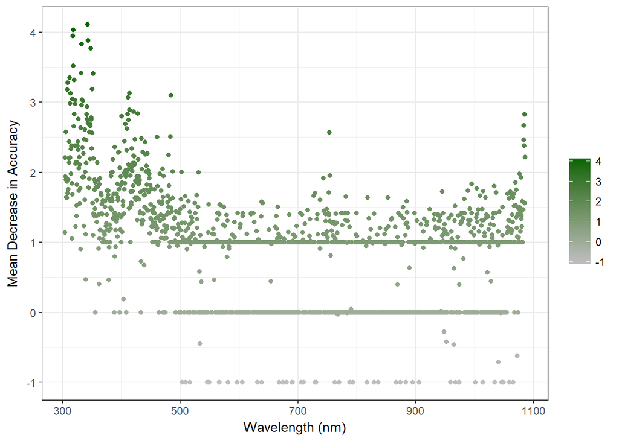

```r
## Transformation: normalized. Classification: Aflatoxin.
MDA(mod_rf_norm_af$finalModel)
```

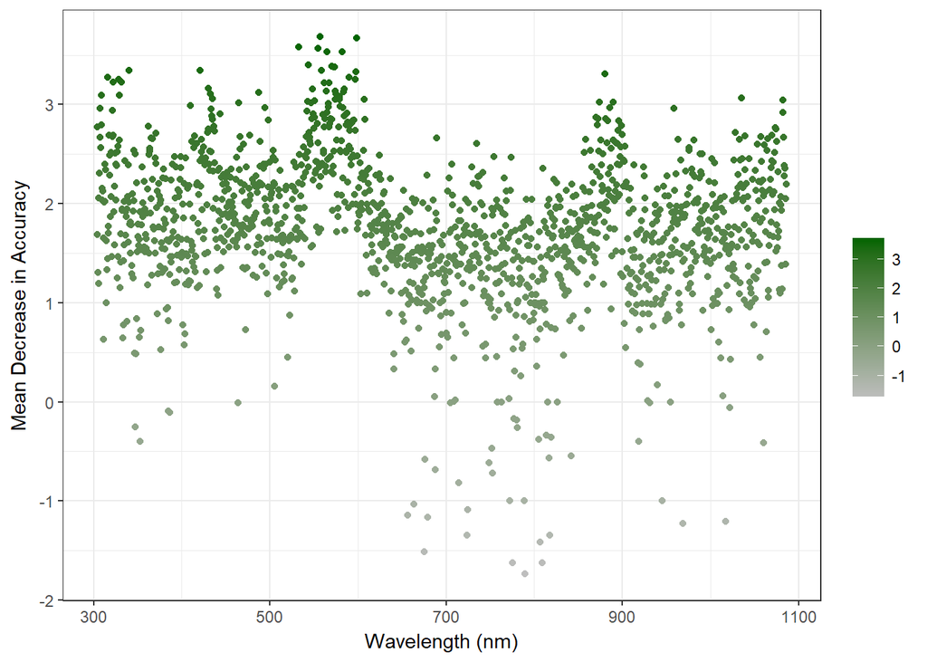

```r
## Transformation: normalized. Classification: Fumonisin.
MDA(mod_rf_norm_fm$finalModel)
```